# Dansk Realkredit

Maskinen bag boligfinansieringen

Niklas Lehmann Jensen

## Introduktion

#### Dagens spørgsmål

- Hvordan forbinder systemet **låntager, institut og investor**?
- Hvorfor er **balanceprincippet** og **match-funding** så centrale?
- Hvad er forskellen på **kupon, bidrag** og **obligationstillæg**?
- Hvorfor kræver konverterbare lån **adfærdsmodeller**?

#### Læringsmål

- Forbindelsen låntager → institut → investor
- Hvorfor balanceprincip og match-funding er vigtige
- Reglerne der begrænser kreditrisikoen
- De vigtigste lånetyper og deres risici
- Hvem betaler/modtager hvad: kupon, bidrag, tillæg
- Hvorfor konverterbare kræver kapitel 6 og 7

## Baggrund: Københavns brand 1795

- **5. juni 1795** — byen brænder i 2 dage
- **941 huse** ødelagt → akut behov for **kapital**
- Spørgsmålet: *hvem skulle låne ud?*

## Løsningen: Kreditkassen

- Långivere slog sig sammen: **Husejernes Kreditkasse**
- Lav rente krævede lav kreditrisiko → **pant** + **solidarisk hæftelse**
- Ingen konkurs på en obligationsserie i **200 år**

## Realkreditsystemet

#### Tre-parts-systemet

[figure not shown]

#### Balanceprincippet & match-funding

**Definition**

**Balanceprincippet:** lån og obligationer skal hænge tæt sammen på betalinger og risici. **Match-funding:** obligationer udstedes med lånets centrale egenskaber — valuta, løbetid, afdragsprofil, rentetype.

- Risiko forsvinder ikke — den **placeres**
- Kredit hos instituttet · rente/likviditet/konvertering hos investor

#### Instituttets balance: $H = D + E$

[figure not shown]

#### Et koncentreret marked

- Få store udstedere: Nykredit/Totalkredit, RD, Nordea Kredit, Jyske, DLR
- Fungerer i høj grad som et **enhedsmarked**
- Høj standardisering vs. individuelle banklån

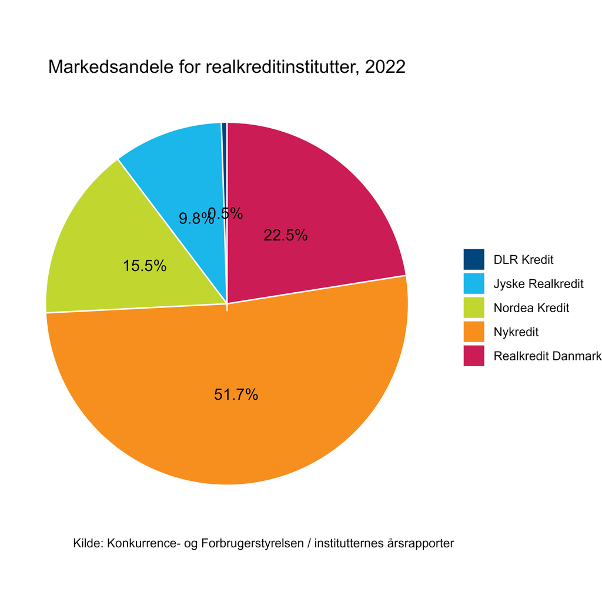

#### Obligationsserier: match-funding i praksis

- Lån samles i store **serier** → volumen + likviditet
- Serie er **åben** for nyudstedelse → lukkes → nye lån i en **ny serie**
- Låntager vælger ikke en abstrakt rente, men et lån i en **konkret serie til en konkret kurs**

| Åben RD-serie (fast) | Kurs |
| --- | --- |
| 30-år afdrag, 4 % 2056 | 97,450 |
| 30-år IO10, 4 % 2056 | 96,600 |
| 20-år afdrag, 4 % 2046 | 98,518 |
| 10-år afdrag, 3 % 2036 | 97,710 |

#### Bidrag vs. kupon vs. obligationstillæg

$$\text{Låntagers ydelse} = \underbrace{\text{rente} + \text{afdrag}}_{\text{→ investor}} + \underbrace{\text{bidrag}}_{\text{→ instituttet}}$$

- **Kupon** = obligationens rente → investor
- **Obligationstillæg** = markedsbestemt del af floater-kupon → investor
- **Bidrag** indgår **IKKE** i obligationens betalingsrække

## Lovgivning & regulering

#### LTV: belåningsgrænser

$$\text{LTV} = \frac{\text{Restgæld}}{\text{Estimeret ejendomsværdi}}$$

| Ejendomstype | Maks. LTV |
| --- | --- |
| Helårsbolig | 80 % |
| Sommerhus | 75 % |
| Erhverv | 60 % |
| Landbrug | 60 % |

- Bolig 4 mio., lån 3,2 mio. → **LTV = 80 %**
- Tinglysning = **pant** → prioritet ved tvangsauktion

#### Tilsynsdiamanten

Fem pejlemærker begrænser systemisk risiko:

- Udlånsvækst
- Høj LTV + kort rentebinding
- Høj LTV + afdragsfrihed
- Refinansiering (koncentration)
- Store enkelteksponeringer

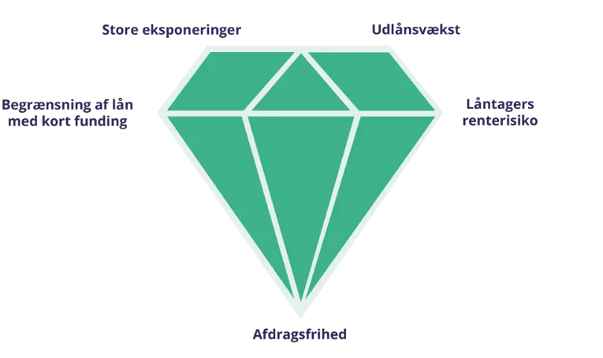

#### RO, SDRO og SDO

- Juridiske typer; **SDRO/SDO** standard efter 2007
- Boligprisfald → LTV over grænsen → institut skal stille **supplerende sikkerhed**
- Sikkerheden er værdifuld — men ikke gratis

## Markedet

#### Realkredit fylder meget

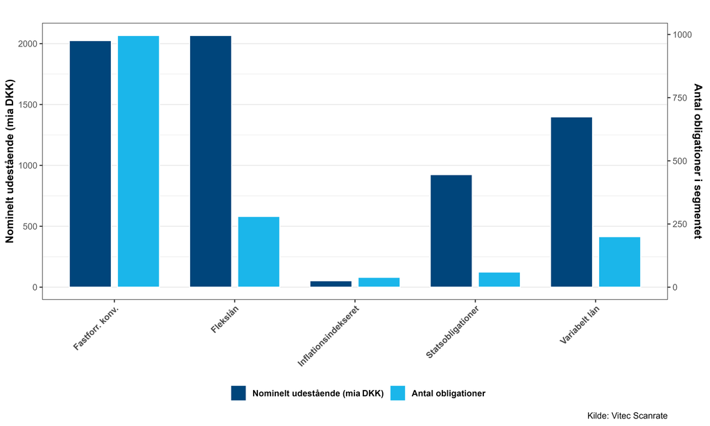

#### Kurslisten: MTG / FLT / RTL

| Obligation | Kurs | Kupon | Type | Konv. | Afdragsfri | Udløb |
| --- | --- | --- | --- | --- | --- | --- |
| 1 RD T RTL 2027 Jan | 98,936 | 1,000 | RTL | Nej | Nej | 2027 |
| 5 NYK E MTG 2053 | 103,995 | 5,000 | MTG | Ja | Nej | 2053 |
| 4 NYK E MTG 2056 | 99,233 | 4,000 | MTG | Ja | Nej | 2056 |
| 2,202 NYK H FLT 2028 | 100,170 | 2,202 | FLT | Nej | Ja | 2028 |
| 5 NYK E MTG 2053 IO10 | 103,660 | 5,000 | MTG | Ja | Ja | 2053 |

- **MTG** lange fastforrentede (typisk konverterbare) · **FLT** variabelt forrentede · **RTL** rentetilpasning

#### Kursværdi & låntagers provenu

$$\text{Kursværdi} = \frac{K}{100}\,H$$
I ord: kursen afgør, hvor meget låntager reelt får udbetalt.

$$\frac{98}{100}\cdot 1.000.000 = 980.000 \text{ kr.}$$

- Nominel gæld 1.000.000 ≠ markedsværdi af gæld

## De tre realkreditprodukter

#### Produkt 1: fast konverterbart lån

**Låntager**

- 30 år, fast kupon, annuitet
- Budgetsikkerhed
- **Konverteringsret**

**Investor**

- Lang fast kupon
- Kort en option til låntager
- Usikker betalingsrække
- Indfri til **markedskurs** (rente↑) eller opsig til **kurs 100** (rente↓)

#### Konverteringsret = negativ konveksitet

**Indsigt**

Fordi låntager kan indfri til **kurs 100**, kan kursen ikke stige meget over 100 — uanset hvor meget renten falder.

- Kursgevinst ved rentefald: **begrænset**
- Kurstab ved rentestigning: **ikke begrænset**
- = lav/negativ konveksitet (kap. 4 → kap. 7)

#### Konvertering & genplaceringsrisiko

- Terminer 1/1 · 1/4 · 1/7 · 1/10 — udtræk = **ordinært + ekstraordinært** (→ kap. 6 $UDT_t$)

[figure not shown]

#### Produkt 2: floater / F-kort

$$\text{Næste kupon} = \text{referencerente}_{\text{fixing}} + \text{tillæg}$$

- Fixing før, betaling efter
- Lav varighed → handler tæt på **100**
- Tillæg → investor (**ikke** bidrag!)

[figure not shown]

#### Auktionen: markedet finder marginen

$$\begin{array}{rcl}\text{Fastforrentet} &:& \text{fast kupon} \Rightarrow \text{markedet finder kursen}\\ \text{Floater ved auktion} &:& \text{kurs} \approx 100 \Rightarrow \text{markedet finder marginen}\end{array}$$

| Obligation | Reference | Tillæg | Auktionskurs |
| --- | --- | --- | --- |
| RD grøn FRN Jul-2030 | CIBOR 6M | −15 bp | 100,300 |
| RD FRN Jul-2030 | CITA 6M | 50 bp | 100,300 |

#### Produkt 3: RTL / flekslån

- Rente fast i en periode, så **refinansieres** (F1, F3, F5, …) · ét langt lån, kortere **rullende** funding · rente ved auktion = **markedsresultat**

[figure not shown]

#### RTL-risici & triggere

- **Auktionstrigger:** fejlet auktion → forlæng · **Rentetrigger:** renten hopper for meget → forlæng · = **forlængelsesrisiko** for investor

[figure not shown]

#### Renterisiko: kort vs. lang rentebinding

[figure not shown]

#### De tre lånetyper

|  | Fast konverterbart | Floater / F-kort | RTL / flekslån |
| --- | --- | --- | --- |
| **Rentebinding** | Hele løbetiden | Kort, fixes løbende | Fast mellem F-terminer |
| **Renten sættes af** | Kuponen | Reference + tillæg | Auktion |
| **Konv.ret til 100** | Ja | Normalt nej | Nej |
| **Risiko, låntager** | Højere rente for sikkerhed | Ydelse stiger med korte renter | Ny rente ved refinansiering |
| **Risiko, investor** | Konvertering + genplacering | Kupon falder; tillæg kan skifte | Refinansiering + forlængelse |

## Fra produkt til model

#### Fra maskine til model

- **Inkonverterbar:** fast betalingsrække
- **Floater / RTL:** mekanisk usikker (fixing, auktion)
- **Konverterbar:** afhænger af låntagernes beslutninger → kræver **modeller**
- Kap. 6: CK95/CK92, $CPR_t$, $UDT_t$, burnout — **LYS** (låntager)
- Kap. 7: pris, varighed, konveksitet — **OAS** (investor)

## Afrunding

#### The Takeaways

1. Dansk realkredit forbinder boliglån direkte med obligationsmarkedet via instituttet.
2. Balanceprincip + match-funding reducerer instituttets markedsrisiko, men *placerer* risiko hos alle tre parter.
3. Kupon + afdrag → investor · bidrag → institut · obligationstillæg → investor (variabelt forrentede).
4. Konverterbare kræver modeller, fordi låntagernes konvertering ændrer investors cash flows.

#### Øvelser

1. Balanceprincip & LTV
2. Kursværdi & provenu
3. Konvertering (ned/op)
4. Bidrag, kupon & tillæg
5. FRN, F-kort & RTL
6. F3-funding (brug backup-eksemplet)

# Appendix / Backup

#### Quoted margin vs. discount margin

$$P = \sum_{i=1}^{T}\frac{100\,(r_i^{\text{ref}}+q)\,\Delta_i}{\left(1+z_{t_i}+s\right)^{t_i}} + \frac{100}{\left(1+z_{t_T}+s\right)^{t_T}}$$

- **Quoted margin** $q$ i **tælleren** (i kuponen) · **Discount margin** $s$ i **nævneren** (investors effektive spænd)
- Tæt på kurs 100 ligger de tæt; overkurs → effektivt spænd lavere

#### F3-funding: balanceprincippet i praksis

$$\begin{aligned}
1{,}01Z_1 + 0{,}01Z_2 + 0{,}01Z_3 &= \bar R\,RG_0\\
1{,}01Z_2 + 0{,}01Z_3 &= \bar R\,RG_0\\
1{,}01Z_3 &= (1+\bar R)\,RG_0\\
k_0^1Z_1 + k_0^2Z_2 + k_0^3Z_3 &= RG_0
\end{aligned}$$

Med $k_0^1{=}0{,}99,\ k_0^2{=}0{,}975,\ k_0^3{=}0{,}96,\ RG_0{=}1.000.000$:
$$Z_1{=}13.540{,}75,\quad Z_2{=}13.676{,}16,\quad Z_3{=}1.013.812{,}92,\quad \bar R{=}2{,}395\%$$

#### Markedsbevægelser & nye serier

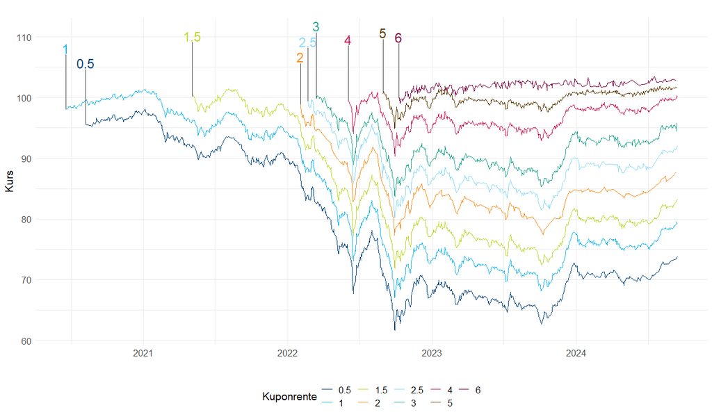

Nye serier ved rentestigning, 2022 (Scanrate)

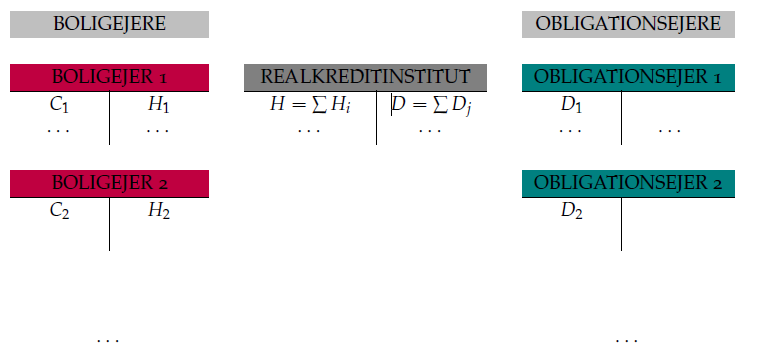

Skematisk opbygning (Tanggaard 2024)